# Assignment_6_Stats_II_Group_22

Maik David Klaiber (22-482-426)

Jonas Weber (24-621-484)

Yann Rochaix (24-622-276)

26.05.2026

# Part 0

We import the dataset with `sep=";"` and use`skim(df)` to get a first overview of our data. Then, we processed the usual cleaning steps.

```r
# Load the data set
df <- read.csv("careworkers_did.csv", sep=";")
```

```r
# Summarize the data
skim(df)

# Replace invalid values with NA
df$CAREWORKERS[df$CAREWORKERS == -9999999] <- NA
df$YIAR[df$YIAR == -1] <- NA

# Shorten country names
df$COUNTRY <- gsub("Country ", "", df$COUNTRY)

# Rename column
names(df)[names(df) == "YIAR"] <- "YEAR"

# Summarize cleaned data
skim(df)
```

# Part I

**1. Generating two dummy variables for difference-in-differences estimation**

```r
# Create POST dummy
df$POST <- ifelse(df$YEAR > 1992, 1, 0)

# Create TREATED dummy
df$TREATED <- ifelse(df$COUNTRY == "A", 1, 0)
```

**2. Key assumption of difference-in-differences estimation**

The key assumption of the difference-in-differences estimation is that treatment and control groups would have evolved in parallel in the absence of treatment.

**3. Visual evidence of key assumption**

First, we created a sketch of the difference-in-differences (DiD) framework discussed in the lecture in order to illustrate the intuition behind the parallel trends assumption and the treatment effect.

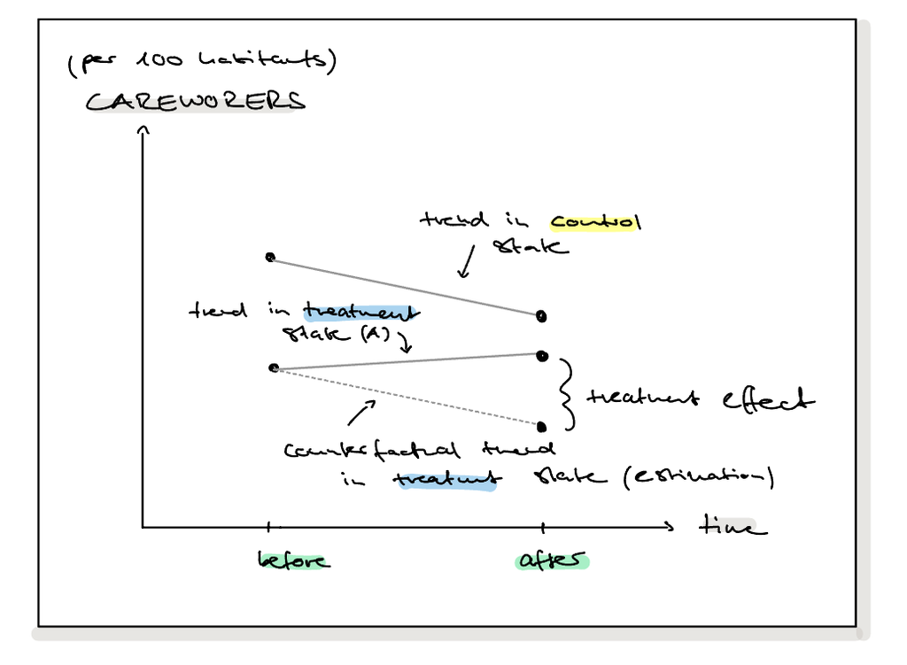

Next, we assess whether the key assumption underlying the DiD approach, the parallel trends assumption, appears to hold in our data. In particular, we examine whether the two countries followed similar trends before the reform was implemented in 1993. The graph below suggests that this assumption is reasonably satisfied.

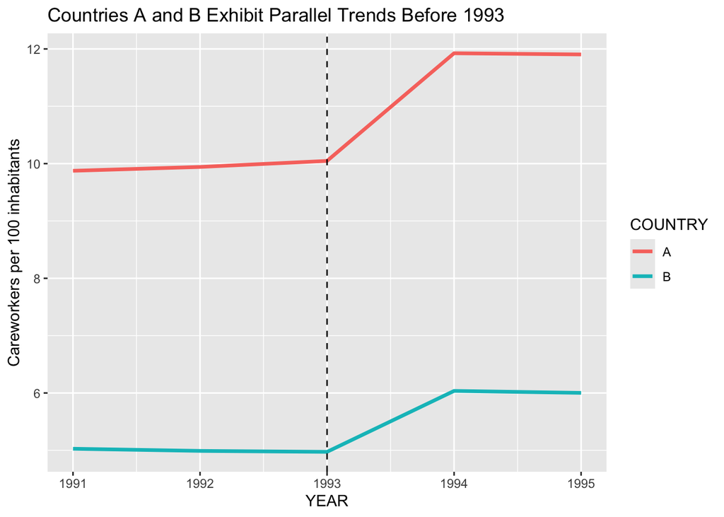

```r
avg_df <- aggregate(CAREWORKERS ~ YEAR + COUNTRY,
                    data = df,
                    mean)

ggplot(avg_df,
       aes(x = YEAR,
           y = CAREWORKERS,
           color = COUNTRY)) +
  geom_line(size = 1.2) +
  geom_vline(xintercept = 1993,
             linetype = "dashed") +
  labs(title = "Countries A and B Exhibit Parallel Trends Before 1993",
       y = "Careworkers per 100 inhabitants")
```

**4. Formal evidence with regression**

To formally test the parallel trends assumption, we estimate the following regression model using only *pre-reform* observations:

$$CAREWORKERS_{it} = \alpha + \beta_1 YEAR_t + \beta_2 TREATED_i + \beta_3
(YEAR_t \times TREATED_i) + \varepsilon_{it}$$

```r
#Setup DiD regression

pre_df <- subset(df, YEAR < 1993)

parallel_model <- lm(CAREWORKERS ~ YEAR * TREATED,
                     data = pre_df)

summary(parallel_model)
```

```
##
## Call:
## lm(formula = CAREWORKERS ~ YEAR * TREATED, data = pre_df)
##
## Residuals:
##     Min      1Q  Median      3Q     Max
## -6.4341 -0.9559 -0.0084  0.9492  7.2207
##
## Coefficients:
##                Estimate Std. Error t value Pr(>|t|)
## (Intercept)    80.01889  145.88753   0.548    0.583
## YEAR           -0.03766    0.07326  -0.514    0.607
## TREATED      -203.84718  206.69248  -0.986    0.324
## YEAR:TREATED    0.10482    0.10379   1.010    0.313
##
## Residual standard error: 1.608 on 3836 degrees of freedom
##   (42 observations deleted due to missingness)
## Multiple R-squared:  0.6992, Adjusted R-squared:  0.6989
## F-statistic:  2972 on 3 and 3836 DF,  p-value: < 2.2e-16
```

The interaction term between `YEAR` and `TREATED` is not statistically significant (`p = 0.313`), suggesting that the treatment and control groups followed similar trends prior to the reform. This provides supportive evidence for the parallel trends assumption.

**5. Plausibility of the key assumption**

Based on both the visual inspection and the regression analysis, the parallel trends assumption appears plausible in this context.

**6. Potential concern in structure of data**

A potential concern is that other structural differences or policy changes between the two countries may have affected the number of careworkers independently of the reform.

# Part II

**1. Estimation of the DiD regression model**

```r
#Estimation
did_model <- lm(CAREWORKERS ~ POST + TREATED + POST * TREATED, data = df)
summary(did_model)
```

```
##
## Call:
## lm(formula = CAREWORKERS ~ POST + TREATED + POST * TREATED, data = df)
##
## Residuals:
##     Min      1Q  Median      3Q     Max
## -7.6184 -1.0434 -0.0069  1.0245  8.5076
##
## Coefficients:
##              Estimate Std. Error t value Pr(>|t|)
## (Intercept)   5.00937    0.04026 124.415   <2e-16 ***
## POST          0.66070    0.05199  12.708   <2e-16 ***
## TREATED       4.89932    0.05705  85.885   <2e-16 ***
## POST:TREATED  0.72802    0.07365   9.885   <2e-16 ***
## ---
## Signif. codes:  0 '***' 0.001 '**' 0.01 '*' 0.05 '.' 0.1 ' ' 1
##
## Residual standard error: 1.767 on 9594 degrees of freedom
##   (387 observations deleted due to missingness)
## Multiple R-squared:  0.7033, Adjusted R-squared:  0.7032
## F-statistic:  7581 on 3 and 9594 DF,  p-value: < 2.2e-16
```

**2. Main coefficient of interest**

The main coefficient of interest is $\beta_3$ (the coefficient on the interaction term $POST \times TREATED$), because it captures the difference-in-differences estimator which is the causal effect of the reform on the treated country (Country A) over and above any time trend or baseline group difference.

**3. Interpretation of $\hat\beta_3$**

$\hat\beta_3$ measures the average change in the number of careworkers per 100 inhabitants in Country A after the reform, relative to the counterfactual trend captured by Country B which is the causal treatment effect of the tax exemption reform.

**4. Interpretation of the other coefficients**

| Coefficient | Interpretation |
| --- | --- |
| $\hat{\beta}_0$ | The average number of careworkers per 100 inhabitants in Country B before the reform. |
| $\hat{\beta}_1$ (POST) | The average change in careworkers after 1992 for Country B (the control group), capturing the common time trend. |
| $\hat{\beta}_2$ (TREATED) | The average difference in careworkers between Country A and Country B before the reform, capturing pre-existing baseline differences. |

**5. Was the reform succesful?**

Yes, the reform was successful: the coefficient on the interaction term $\hat{\beta}_3 = 0.728$ (`POST:TREATED`) is positive and highly statistically significant ($t = 9.885$, $p < 2 \times 10^{-16}$), indicating that the tax exemption reform increased the number of careworkers per 100 inhabitants in Country A by approximately 0.73 additional careworkers relative to Country B after 1992.